# Hierarchical Sampling Model

```r
library(sampinfo)
library(bayesplot)
library(rstan)
library(knitr)
```

## Prepare the data:

To begin with, we have a dataset with many participants, each finishing a same set of questions. Within each question, there are several time points, where the participant samples from a set of C options.  
In this toy dataset, total participant number $S=10$. The participant ID is listed in *sID*.

```r
subset(sampinfo::raw_data, qID==1)
```

```
#>     qID sID final_choice tNo cID rating terminate
#> 1     1   1            1   1   5      3         1
#> 35    1   2            1   1   5      3         0
#> 36    1   2            1   2   5      2         0
#> 37    1   2            1   3   4      0         0
#> 38    1   2            1   4   7      3         0
#> 39    1   2            1   5   5      3         1
#> 85    1   3            1   1   5      3         0
#> 86    1   3            1   2   7      3         0
#> 87    1   3            1   3   5      3         0
#> 88    1   3            1   4   7      3         1
#> 115   1   4            1   1   6      3         0
#> 116   1   4            1   2   5      3         0
#> 117   1   4            1   3   5      3         1
#> 152   1   5            1   1   5      3         0
```

[output cut: 19 more lines]

Total question number $Q = 5$. The question ID for each sampling time point is stored in *qID*.

```r
subset(sampinfo::raw_data, sID==1)
```

```
#>    qID sID final_choice tNo cID rating terminate
#> 1    1   1            1   1   5      3         1
#> 2    2   1            1   1   4      0         0
#> 3    2   1            1   2   3     -1         0
#> 4    2   1            1   3   6      3         1
#> 5    3   1            1   1   6      3         0
#> 6    3   1            1   2   2     -3         0
#> 7    3   1            1   3   6      2         1
#> 8    4   1            1   1   5      3         0
#> 9    4   1            1   2   7      3         0
#> 10   4   1            1   3   5      3         0
#> 11   4   1            1   4   5      2         0
#> 12   4   1            1   5   6      3         1
#> 13   5   1            0   1   2     -3         0
#> 14   5   1            0   2   6      3         0
#> 15   5   1            0   3   4      0         0
#> 16   5   1            0   4   1     -3        -1
```

The time points within a question are saved in *tNo*. For the model fitting code with flexible decay to work, we need to make sure that sampling decisions for a same participant and same question are stored together in the formmated data, and that the *tNo*s start from 1 and are consecuuttive.  
There are in total 7 options, and choices are indicated using integers from 1 to 7. This variable is saved in *cID*,

Now we add feature values of the options to the dataset. In this example, we have three features: sameC, sameA and dist.

- sameC: whether the option (i.e., thought cluster) is the same as the one sampled in the previous time point
- sameA: whether they are decision congruent
- dist: the semantic distance between the option and the previously sampled option

```r
head(sampinfo::format_data,6)
```

```
#>    qID sID final_choice tNo cID rating terminate sameC_1 sameC_2 sameC_3
#> 1    1   1            1   1   5      3         1       0       0       0
#> 35   1   2            1   1   5      3         0       0       0       0
#> 36   1   2            1   2   5      2         0       0       0       0
#> 37   1   2            1   3   4      0         0       0       0       0
#> 38   1   2            1   4   7      3         0       0       0       0
#> 39   1   2            1   5   5      3         1       0       0       0
#>    sameC_4 sameC_5 sameC_6 sameC_7 sameA_1 sameA_2 sameA_3 sameA_4 sameA_5
#> 1        0       0       0       0       0       0       0       0       0
#> 35       0       0       0       0       0       0       0       0       0
#> 36       0       1       0       0       0       0       0       0       1
#> 37       0       1       0       0       0       0       0       0       1
#> 38       1       0       0       0       0       0       0       1       0
#> 39       0       0       0       1       0       0       0       0       1
#>    sameA_6 sameA_7    dist_1    dist_2    dist_3    dist_4    dist_5    dist_6
#> 1        0       0 0.0000000 0.0000000 0.0000000 0.0000000 0.0000000 0.0000000
#> 35       0       0 0.0000000 0.0000000 0.0000000 0.0000000 0.0000000 0.0000000
#> 36       1       1 0.7219746 0.5405647 0.1962040 0.3430576 0.0000000 0.6716426
#> 37       1       1 0.7219746 0.5405647 0.1962040 0.3430576 0.0000000 0.6716426
#> 38       0       0 0.4383020 0.4263575 0.3222916 0.0000000 0.3430576 0.4195917
#> 39       1       1 0.6434015 0.2935061 0.5252062 0.4245322 0.4727024 0.5983119
#>       dist_7
#> 1  0.0000000
#> 35 0.0000000
#> 36 0.4727024
#> 37 0.4727024
#> 38 0.4245322
#> 39 0.0000000
```

## Understand the model:

### Basics:

Our goal is to predict the probabilities of sampling different options at each time point, using known features of the options.

To start simple, let’s use a single feature to predict sampling probabilities. For a trial with C options, we can then write the feature values into a length-$C$ column vector
$$\boldsymbol{X_{C\times1}} = [x_1, x_2, ..., x_C]^T$$
Now we assume the effect can be captured by a linear multiplier $\beta$, and that the predicted choice $Y$ follows a categorical distribution
$$Y \sim Cat(Softmax(\boldsymbol{X_{C\times1}}\beta))$$

In a case with $K$ features, the feature values can be stored in a $C\times K$ matrix, $\boldsymbol{X}$.

In our formatted data, feature values for different options at time $t$ of participant $s$ in question $q$ is stored in a row. For example

```r
subset(sampinfo::format_data,sID==1&qID==2&tNo==3)
```

```
#>   qID sID final_choice tNo cID rating terminate sameC_1 sameC_2 sameC_3 sameC_4
#> 4   2   1            1   3   6      3         1       0       0       1       0
#>   sameC_5 sameC_6 sameC_7 sameA_1 sameA_2 sameA_3 sameA_4 sameA_5 sameA_6
#> 4       0       0       0       1       1       1       0       0       0
#>   sameA_7    dist_1    dist_2 dist_3    dist_4    dist_5    dist_6    dist_7
#> 4       0 0.6608859 0.3896948      0 0.4454363 0.1969848 0.7179708 0.6899078
```

For this row, the associated $\boldsymbol{X^{s,q,t}}$ is

```r
sampinfo::getFeatureMatrices(beta = c('sameC', 'sameA', 'dist'),
                             subset(sampinfo::format_data,sID==1&qID==2&tNo==3),
                             deltaM_value = 0, option_num = 7, print_names = T)[[1]]
```

```
#>         sameC sameA      dist
#> Option1     0     1 0.6608859
#> Option2     0     1 0.3896948
#> Option3     1     1 0.0000000
#> Option4     0     0 0.4454363
#> Option5     0     0 0.1969848
#> Option6     0     0 0.7179708
#> Option7     0     0 0.6899078
```

Their effects can be captured by a length-$K$ vector $\boldsymbol{\beta}$. For example, in our example, $\boldsymbol{\beta} = [\beta_{sameC},\beta_{sameA},\beta_{dist}]^T$.

The predicted sampling probability
$$Y \sim Cat(Softmax(\boldsymbol{X_{C\times K}}\boldsymbol{\beta_{K\times1}})$$

Hereafter, to denote that the feature matrix $X$ varies among participants, questions and time points, we use superscripts to indicate to which participant, question and time point the matrix applies. For participant $s$, question $q$ and time point $t$:
$$Y^{s,q,t} \sim Cat(Softmax(\boldsymbol{X^{s,q,t}_{C\times K}}\boldsymbol{\beta_{K\times1}})$$

Now we have a the model for predicting the sampling probability at each time point, using a single $\boldsymbol{\beta}$ for all the participants anad questions. Very simple.

### Hiearchical structure:

Now how about heterogeneity across participants and questions? We need a *hiearchical model* to address that. In this part we specify how to model the feature effects for participant $s$ in question $q$, i.e., $\boldsymbol{\beta^{s,q}}$, .

To start, we assume there is a grand mean for each of the K features’ effects. We denote the mean effects as length-$K$ column vector $\boldsymbol{\mu}$.

We then assume that the $S$ participants deviate from the grand mean on each of the $K$ features. Here the deviations can be written as $\boldsymbol{\eta_{S}}$, a matrix of size $K \times S$. Column $s$ of this matrix, $\boldsymbol{\eta_{S}}[*,s]$ represents deviations of participant $s$ on the $K$ features. Similarly, the deviations of the $Q$ questions on the features can be written as $\boldsymbol{\eta_{Q}}$, a $K\times Q$ matrix. Column $q$ of this matrix, $\boldsymbol{\eta_{Q}}[*,q]$ represents deviations of question $q$ on the $K$ features.

Therefore, for participant $s$ and question $q$, the feature effects
$$\boldsymbol{\beta^{s,q}}=\boldsymbol{\mu}+\boldsymbol{\eta_{S}}[*,s]+\boldsymbol{\eta_{Q}}[*,q]$$
the sampling choice
$$Y^{s,q,t} \sim Cat(Softmax(\boldsymbol{X^{s,q,t}}\boldsymbol{\beta^{s,q}})$$

If we extract a row of of the deviation matrices, its elements reprersent deviations of different participants (or questions) on a single feature. We assume that for a single feature, the deviations of the participants (or questions) follows a centered Normal distribution. Under this assumption, we need scale parameters to quantify these deviations. For participant and question level deviations, the scale parameters are $\boldsymbol{\sigma_{S}}$ and $\boldsymbol{\sigma_{Q}}$ respectively. $\boldsymbol{\sigma_{S}}$ and $\boldsymbol{\sigma_{Q}}$ are both length-$K$ column vectors. Therefore for feature $k$, we have:
$$\boldsymbol{\eta_{S}}[k,*] \sim Normal(0,\boldsymbol{\sigma_{S}}[k])\\
\boldsymbol{\eta_{Q}}[k,*] \sim Normal(0,\boldsymbol{\sigma_{Q}}[k])$$
Or equivelently,
$$\boldsymbol{\theta_{S}}[k,*] \sim Normal(0,1),\ \boldsymbol{\eta_{S}}[k,*] = \boldsymbol{\sigma_{S}}[k] \boldsymbol{\theta_{S}}[k,*]\\
\boldsymbol{\theta_{Q}}[k,*] \sim Normal(0,1),\ \boldsymbol{\eta_{Q}}[k,*] = \boldsymbol{\sigma_{Q}}[k] \boldsymbol{\theta_{Q}}[k,*]\\$$
To summarize, the parameters we need to fit include:

- $\boldsymbol{\mu}$: a length-$K$ column vector for grand mean effects
- $\boldsymbol{\sigma_{S}}$: a length-$K$ column vector. SD for patcipant-level deviations
- $\boldsymbol{\sigma_{Q}}$: a length-$K$ column vector. SD for question-level deviations
- $\boldsymbol{\eta_{S}}$: a $K\times S$ matrix. All partcipant-level deviations.
- $\boldsymbol{\eta_{Q}}$: a $K\times Q$ matrix. All question-level deviations.

Note that if we use the second parameterizatiton for $\boldsymbol{\eta_{S}}$ and $\boldsymbol{\eta_{Q}}$, then we are fitting $\boldsymbol{\theta_{S}}$ and $\boldsymbol{\theta_{Q}}$ in stead of $\boldsymbol{\eta_{S}}$ and $\boldsymbol{\eta_{Q}}$. For the differences between these two approaches, please refer to the discussion of *Neal’s Funnel* in the last section of this document.

### Other specifications:

Beyond these we also assume different base rates for different questions (no participant level difference on this matter).

Finally we can implement memory of previous time points, so that not only the feature values of the current time points influence sampling behaviors. In other words, we assume that at time point 1 of each question, the accumulative feature value matrix:
$$\boldsymbol{A^{s,q,1}}=\boldsymbol{X^{s,q,1}}$$
And for $t > 1$,
$$\boldsymbol{A^{s,q,t}}=\delta\boldsymbol{A^{s,q,t-1}} + \boldsymbol{X^{s,q,t}}$$
The predicted sampling probability
$$Y^{s,q,t} \sim Cat(Softmax(\boldsymbol{A^{s,q,t}}\boldsymbol{\beta^{s,q}})$$

When $\delta=1$, participants have full memory. For participant 1 and question 2, there are three time points and the feature value matrices are

```r
sampinfo::getFeatureMatrices(beta = c('sameC', 'sameA', 'dist'),
                             subset(sampinfo::format_data,sID==1&qID==2),
                             deltaM_value = 0, option_num = 7, print_names = T)
```

```
#> [[1]]
#>         sameC sameA dist
#> Option1     0     0    0
#> Option2     0     0    0
#> Option3     0     0    0
#> Option4     0     0    0
#> Option5     0     0    0
#> Option6     0     0    0
#> Option7     0     0    0
#>
#> [[2]]
#>         sameC sameA      dist
#> Option1     0     0 0.3266013
#> Option2     0     0 0.4155570
#> Option3     0     0 0.4454363
#> Option4     1     1 0.0000000
#> Option5     0     0 0.4043892
#> Option6     0     0 0.4440681
#> Option7     0     0 0.3322981
#>
#> [[3]]
#>         sameC sameA      dist
#> Option1     0     1 0.6608859
#> Option2     0     1 0.3896948
#> Option3     1     1 0.0000000
#> Option4     0     0 0.4454363
#> Option5     0     0 0.1969848
#> Option6     0     0 0.7179708
#> Option7     0     0 0.6899078
```

The accumulative feature value matrix should be:

```r
sampinfo::getFeatureMatrices(beta = c('sameC', 'sameA', 'dist'),
                             subset(sampinfo::format_data,sID==1&qID==2),
                             deltaM_value = 1, option_num = 7, print_names = T)
```

```
#> [[1]]
#>         sameC sameA dist
#> Option1     0     0    0
#> Option2     0     0    0
#> Option3     0     0    0
#> Option4     0     0    0
#> Option5     0     0    0
#> Option6     0     0    0
#> Option7     0     0    0
#>
#> [[2]]
#>         sameC sameA      dist
#> Option1     0     0 0.3266013
#> Option2     0     0 0.4155570
#> Option3     0     0 0.4454363
#> Option4     1     1 0.0000000
#> Option5     0     0 0.4043892
#> Option6     0     0 0.4440681
#> Option7     0     0 0.3322981
#>
#> [[3]]
#>         sameC sameA      dist
#> Option1     0     1 0.9874872
#> Option2     0     1 0.8052518
#> Option3     1     1 0.4454363
#> Option4     1     1 0.4454363
#> Option5     0     0 0.6013740
#> Option6     0     0 1.1620389
#> Option7     0     0 1.0222058
```

Now let’s take a break from maths…

And have a look at the code.

### Stan codes:

```
sampinfo::getStanCode(0)
> S4 class stanmodel 'mm10d01' coded as follows:
>
> data{
>   // memory
>   int deltaM_value; // number of option categories
>   int<lower=2> C; // number of option categories
>   int<lower=0> K; // number of features; if 0 then no betas
>   int<lower=1> N; // number of time points
>   int<lower=1> S; // number of participants
>   int<lower=1> Q; // number of questions
>   int<lower=0> sID[N]; // participant ID variable
>   int<lower=0> qID[N]; // question ID variable
>   matrix[C,K] X[N]; // feature matrix, for different time points
>   int<lower=1, upper=C> cID[N]; // response cluster ID, 1-7 for 3-cluster solution
> }
>
> parameters{
>   matrix[C-1,Q] alpha_raw; // base rate
>   vector[K] beta_mu; // group-level mean for beta
>   vector<lower=0>[K] beta_s_sd; // sd for beta across individuals
>   vector<lower=0>[K] beta_q_sd; // sd for beta across questions
>   matrix[K,Q] beta_q_raw; // question-level beta
>   matrix[K,S] beta_s_raw; // individual-level beta
> }
>
> transformed parameters {
>   matrix[C,Q] alpha;
>   matrix[C,N] theta;
>   matrix[K,S] beta[Q];
>   if (K > 0){
>     for (q in 1:Q){
>     beta[q] = rep_matrix(beta_mu,S) +
>               diag_pre_multiply(beta_s_sd,beta_s_raw) +
>               rep_matrix(beta_q_sd .* beta_q_raw[,q],S);
>     }
>   }
>
>   alpha[1:(C-1),] = alpha_raw/2;
>   alpha[C,] = to_row_vector(rep_array(0,Q));
```

[output cut: 37 more lines]

```
>   for (n in 1:N){
>     log_lik[n] = categorical_logit_lpmf(cID[n]|theta[,n]);
>     dev_m += - 2*log_lik[n];
>   }
>   beta_qdev = diag_pre_multiply(beta_q_sd, beta_q_raw);
>   beta_sdev = diag_pre_multiply(beta_s_sd,beta_s_raw);
>   if(K>0){
>    for (k in 1:K) {
>      beta_q_temp[k] = mean(to_array_1d(beta_qdev[k,]));
>      beta_s_temp[k] = mean(to_array_1d(beta_sdev[k,]));
>      }
>    beta_qmean = rep_matrix(beta_mu+beta_s_temp,Q) + beta_qdev;
>    beta_smean = rep_matrix(beta_mu+beta_q_temp,S) + beta_sdev;
>   }
> }
```

Next let’s add a flexible decay parameter.

```
sampinfo::getStanCode(9)
> S4 class stanmodel 'mm10d9' coded as follows:
>
> data{
>   // memory
>   int<lower=2> C; // number of option categories
>   int<lower=0> K; // number of features; if 0 then no betas
>   int<lower=1> N; // number of time points
>   int<lower=1> S; // number of participants
>   int<lower=1> Q; // number of questions
>   int<lower=0> sID[N]; // participant ID variable
>   int<lower=0> qID[N]; // question ID variable
>   int<lower=1> tNo[N]; // thought No.x; used to reset decay
>   matrix[C,K] X[N]; // feature matrix, for different time points
>   int<lower=1, upper=C> cID[N]; // response cluster ID, 1-7 for 3-cluster solution
> }
>
> parameters{
>   real<lower=0> deltaM; // decay
>   matrix[C-1,Q] alpha_raw; // base rate
>   vector[K] beta_mu; // group-level mean for beta
>   vector<lower=0>[K] beta_s_sd; // sd for beta across individuals
>   vector<lower=0>[K] beta_q_sd; // sd for beta across questions
>   matrix[K,Q] beta_q_raw; // question-level beta
>   matrix[K,S] beta_s_raw; // individual-level beta
> }
>
> transformed parameters {
>   matrix[C,Q] alpha;
>   matrix[C,N] theta;
>   matrix[K,S] beta[Q];
>   if (K > 0){
>     for (q in 1:Q){
>     beta[q] = rep_matrix(beta_mu,S) +
>               diag_pre_multiply(beta_s_sd,beta_s_raw) +
>               rep_matrix(beta_q_sd .* beta_q_raw[,q],S);
>     }
>   }
>
>   alpha[1:(C-1),] = alpha_raw/2;
```

[output cut: 45 more lines]

```
>   for (n in 1:N){
>     log_lik[n] = categorical_logit_lpmf(cID[n]|theta[,n]);
>     dev_m += - 2*log_lik[n];
>   }
>   beta_qdev = diag_pre_multiply(beta_q_sd, beta_q_raw);
>   beta_sdev = diag_pre_multiply(beta_s_sd,beta_s_raw);
>   if(K>0){
>    for (k in 1:K) {
>      beta_q_temp[k] = mean(to_array_1d(beta_qdev[k,]));
>      beta_s_temp[k] = mean(to_array_1d(beta_sdev[k,]));
>      }
>    beta_qmean = rep_matrix(beta_mu+beta_s_temp,Q) + beta_qdev;
>    beta_smean = rep_matrix(beta_mu+beta_q_temp,S) + beta_sdev;
>   }
> }
```

## Try fitting the model to the data:

We will use a vector of feature names to specify which features to include in the model. For example:

```r
beta = c('sameC', 'sameA', 'dist')
```

If we need a baseline model without any features, set

```r
beta = c()
```

Next we need to decide whether we want decay in our model.  
If we assume there is no memory at all (i.e., Markov property), then we set

```r
deltaM_value = 0
```

On the other extreme, if no information is ever forgotten within a question (i.e., no decay). We set

```r
deltaM_value = 1
```

Finally we can estimate $\delta$ as a free parameter. Suppose we need a free parameter for $\delta$, then we can specify

```r
deltaM_value = 9
```

With the data, and the model specifications, we can now fit the model.

```r
beta = c('sameA', 'dist')
stan_data_fit = sampinfo::getStanFit(beta = beta, deltaM_value = 9,
                           option_num = 7, format_data = format_data,
                           save_model_file = NULL, init_values="random",
                           iter_num = 200,chain_num = 4,warmup_num = 100, core_num=4,
                           adapt_delta=0.9, stepsize = 0.1, max_treedepth = 10,
                           refresh=1000, save_warmup = TRUE)
```

To make sure that the samples from the posterior distributions are not biased, we need to make sure the chains converge. Only then are we sampling the stationary distribution of the Marco chain. Because many models take minutes/hours/days/… weeks to run, we need to choose a warm-up number carefully. Try some warmup number, test convergence, and repeat until things look good.

Some methods to check model convergence.

- Check model convergence using traceplots.

```r
posterior_w = rstan::extract(stan_data_fit$stan_fit, inc_warmup = TRUE, permuted = FALSE)
dim(posterior_w)
```

```
#> [1]  200    4 1940
```

```r
lapply(dimnames(posterior_w), head)
```

```
#> $iterations
#> NULL
#>
#> $chains
#> [1] "chain:1" "chain:2" "chain:3" "chain:4"
#>
#> $parameters
#> [1] "deltaM"         "alpha_raw[1,1]" "alpha_raw[2,1]" "alpha_raw[3,1]"
#> [5] "alpha_raw[4,1]" "alpha_raw[5,1]"
```

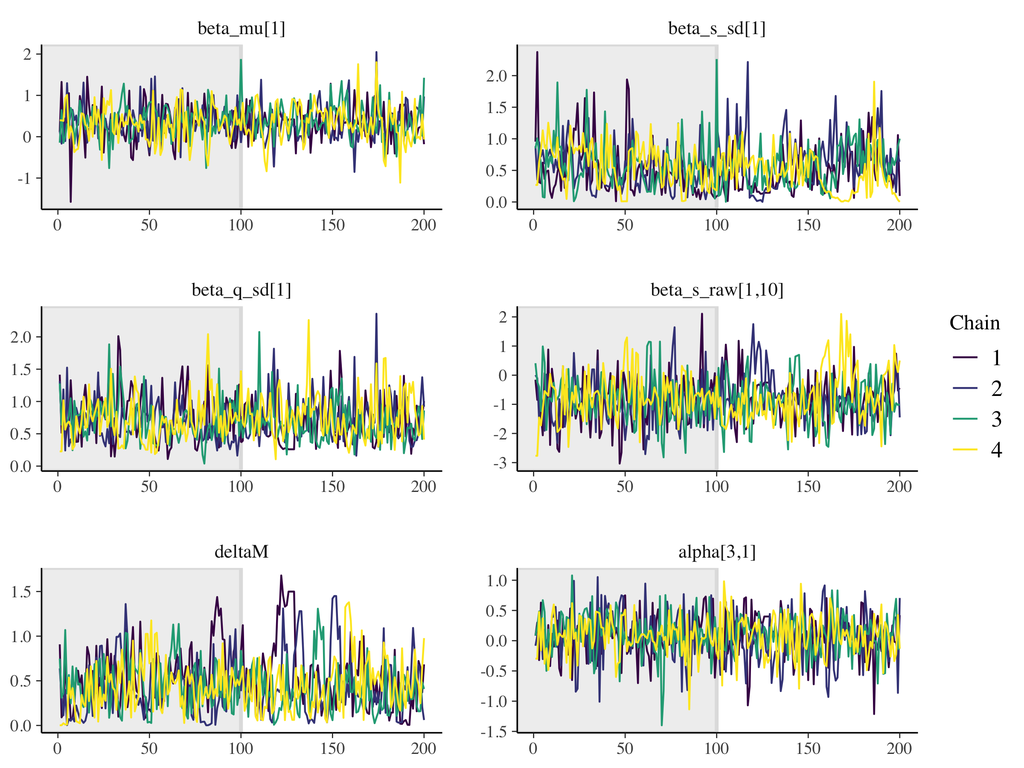

```r
bayesplot::color_scheme_set("viridis")
pars0 = c("beta_mu[1]","beta_s_sd[1]","beta_q_sd[1]","beta_s_raw[1,10]","deltaM","alpha[3,1]")
bayesplot::mcmc_trace(posterior_w, pars = pars0,
                      n_warmup=100, size = 0.5,
                      facet_args = list(nrow = 3))
```

- Another useful plot, which shows us if the ranks of the samples are mixed well among chains.

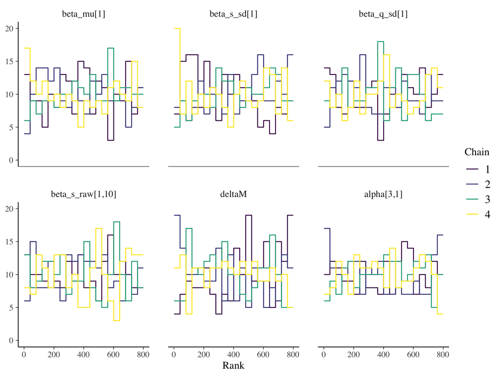

```r
bayesplot::mcmc_rank_overlay(posterior_w, pars = pars0)
```

- Also check gelman-rubin rhat.

```r
rhat = sampinfo::getRhat(stan_data_fit$stan_fit)
print(rhat[rhat>1.05&!is.na(rhat)])
```

```
#>           deltaM     beta_s_sd[1] beta_s_raw[1,10]      theta[1,60]
#>         1.055197         1.087298         1.053247         1.051933
#>      theta[1,61]      theta[2,97]      theta[2,98]      theta[5,97]
#>         1.052093         1.053726         1.052967         1.053479
#>      theta[5,98]      theta[6,97]
#>         1.063804         1.052355
```

## Run the model:

Now take the (conservative) warm-up number, and choose the total iteration number so that the sample size will be enough for the statistics of interests.

```r
stan_data_fit = sampinfo::getStanFit(beta= c('sameA', 'dist'), deltaM_value = 9,
                           option_num = 7, format_data = format_data,
                           save_model_file = NULL, init_values="random",
                           iter_num = 1200,chain_num = 4,warmup_num = 300, core_num=4,
                           adapt_delta=0.9, stepsize = 0.1, max_treedepth = 10,
                           refresh=1000, save_warmup = TRUE)
```

## Check the model diagnostics and goodness of fit:

ESS is effective sample size, 1000 looks good in my opinion.

```r
model_diag = sampinfo::getModelDiag(stan_data_fit = stan_data_fit)
print(model_diag)
```

```
#>      dic_1 dev_mean     pd_1    dic_2  min_dev     pd_2     waic   p_waic
#> 1 749.5508 696.5161 53.03465 729.3835 663.6487 32.86743 726.0886 27.93877
#>        lppd p_waic_1 elapsed_time_min elapsed_time_max rhat_max  ess_min
#> 1 -335.1055 26.30509         22.54261           38.216 1.006804 1046.775
#>   divergent max_tree
#> 1         0        0
```

DIC and WAIC can be used for model comparisons. Lisheng also mentioned Bayes factors, LOO-CV.

Good reference:  
German, A., Hwang, J., & Vehtari, A. (2014). Understanding predictive information criteria for Bayesian models. Statistics and computing, 24(6), 997-1016. [Link](https://arxiv.org/pdf/1307.5928.pdf)

## Summarize and plot parameters

```r
para = sampinfo::getParaSummary(stan_data_fit = stan_data_fit)
print(round(para[1:3,],1))
```

```
#>               mean median 2.5%   5%  10%  20%  25%  50%  75%  80% 90% 95% 97.5%
#> deltaM         0.5    0.4  0.0  0.1  0.1  0.2  0.2  0.4  0.7  0.7 0.9 1.1   1.2
#> beta_sameA_mu  0.4    0.4 -0.5 -0.3 -0.1  0.1  0.1  0.4  0.6  0.7 0.8 1.0   1.1
#> beta_dist_mu  -0.5   -0.5 -1.4 -1.2 -1.1 -0.9 -0.8 -0.5 -0.3 -0.2 0.0 0.2   0.3
#>                sd
#> deltaM        0.3
#> beta_sameA_mu 0.4
#> beta_dist_mu  0.4
```

Here are the question level betas (grand mean plus question-level deviance)

```r
print(round(para[stringr::str_detect(rownames(para),'qmean'),c(1:3,8,13:14)],1))
```

```
#>                    mean median 2.5%  50% 97.5%  sd
#> beta_sameA_qmean_1  0.5    0.5 -0.2  0.5   1.3 0.4
#> beta_dist_qmean_1  -0.5   -0.5 -1.5 -0.5   0.6 0.5
#> beta_sameA_qmean_2  0.2    0.2 -0.4  0.2   0.8 0.3
#> beta_dist_qmean_2  -0.7   -0.6 -1.6 -0.6   0.3 0.5
#> beta_sameA_qmean_3 -0.4   -0.4 -1.2 -0.4   0.4 0.4
#> beta_dist_qmean_3  -0.9   -0.9 -2.0 -0.9  -0.1 0.5
#> beta_sameA_qmean_4  1.0    1.0  0.3  1.0   1.8 0.4
#> beta_dist_qmean_4  -0.5   -0.5 -1.4 -0.5   0.5 0.5
#> beta_sameA_qmean_5  0.7    0.7  0.1  0.7   1.4 0.3
#> beta_dist_qmean_5  -0.4   -0.4 -1.4 -0.4   0.9 0.6
```

and the participant level betas (grand mean plus participant-level deviance)

```r
print(round(para[stringr::str_detect(rownames(para),'smean'),c(1:3,8,13:14)],1))
```

```
#>                     mean median 2.5%  50% 97.5%  sd
#> beta_sameA_smean_1   0.2    0.2 -0.8  0.2   1.0 0.4
#> beta_dist_smean_1   -0.4   -0.4 -1.4 -0.4   1.1 0.6
#> beta_sameA_smean_2   0.3    0.3 -0.3  0.3   1.0 0.3
#> beta_dist_smean_2   -0.7   -0.7 -1.9 -0.7   0.1 0.5
#> beta_sameA_smean_3   0.3    0.3 -0.6  0.3   1.1 0.4
#> beta_dist_smean_3   -0.5   -0.5 -1.5 -0.5   0.8 0.5
#> beta_sameA_smean_4   0.9    0.9  0.2  0.9   2.1 0.5
#> beta_dist_smean_4   -0.5   -0.5 -1.4 -0.5   0.6 0.5
#> beta_sameA_smean_5   0.3    0.3 -0.3  0.3   1.0 0.3
#> beta_dist_smean_5   -0.7   -0.7 -1.8 -0.7   0.1 0.5
#> beta_sameA_smean_6   0.4    0.4 -0.3  0.4   1.1 0.3
#> beta_dist_smean_6   -0.5   -0.5 -1.5 -0.5   0.5 0.5
#> beta_sameA_smean_7   0.4    0.4 -0.4  0.4   1.4 0.4
#> beta_dist_smean_7   -0.5   -0.5 -1.6 -0.5   0.7 0.5
#> beta_sameA_smean_8   0.2    0.2 -0.7  0.2   1.1 0.4
#> beta_dist_smean_8   -0.6   -0.6 -1.7 -0.6   0.6 0.6
#> beta_sameA_smean_9   1.1    1.0  0.1  1.0   2.8 0.7
#> beta_dist_smean_9   -0.8   -0.7 -2.2 -0.7   0.2 0.6
#> beta_sameA_smean_10 -0.1    0.0 -1.2  0.0   0.7 0.5
#> beta_dist_smean_10  -0.8   -0.7 -2.2 -0.7   0.1 0.6
```

Also option base rates in different questions.

```r
print(round(para[stringr::str_detect(rownames(para),'alpha'),c(1:3,8,13:14)],1)[1:20,])
```

```
#>           mean median 2.5%  50% 97.5%  sd
#> alpha.1.1 -0.4   -0.4 -1.2 -0.4   0.4 0.4
#> alpha.2.1 -0.6   -0.6 -1.4 -0.6   0.2 0.4
#> alpha.3.1  0.1    0.1 -0.7  0.1   0.8 0.4
#> alpha.4.1 -0.4   -0.4 -1.2 -0.4   0.3 0.4
#> alpha.5.1  0.7    0.7  0.1  0.7   1.4 0.3
#> alpha.6.1 -0.5   -0.5 -1.3 -0.5   0.2 0.4
#> alpha.7.1  0.0    0.0  0.0  0.0   0.0 0.0
#> alpha.1.2 -0.6   -0.6 -1.4 -0.6   0.1 0.4
#> alpha.2.2 -0.7   -0.7 -1.5 -0.7   0.0 0.4
#> alpha.3.2  0.5    0.5 -0.1  0.5   1.1 0.3
#> alpha.4.2 -0.3   -0.3 -1.0 -0.3   0.4 0.4
#> alpha.5.2 -0.2   -0.2 -0.9 -0.2   0.5 0.4
#> alpha.6.2  0.3    0.3 -0.3  0.3   0.9 0.3
#> alpha.7.2  0.0    0.0  0.0  0.0   0.0 0.0
#> alpha.1.3 -0.3   -0.3 -1.1 -0.3   0.4 0.4
#> alpha.2.3  0.4    0.4 -0.3  0.4   1.0 0.3
#> alpha.3.3  0.1    0.1 -0.6  0.1   0.8 0.3
#> alpha.4.3 -0.7   -0.6 -1.4 -0.6   0.1 0.4
#> alpha.5.3 -0.4   -0.3 -1.1 -0.3   0.4 0.4
#> alpha.6.3  1.2    1.2  0.6  1.2   1.8 0.3
```

There are many ways to visualize the samples. For example, check the bayesplot package [Link](https://mc-stan.org/bayesplot/articles/plotting-mcmc-draws.html)

```r
posterior = rstan::extract(stan_data_fit$stan_fit, inc_warmup = TRUE, permuted = FALSE)
dim(posterior)
```

```
#> [1] 1200    4 1940
```

```r
head(dimnames(posterior)[[3]])
```

```
#> [1] "deltaM"         "alpha_raw[1,1]" "alpha_raw[2,1]" "alpha_raw[3,1]"
#> [5] "alpha_raw[4,1]" "alpha_raw[5,1]"
```

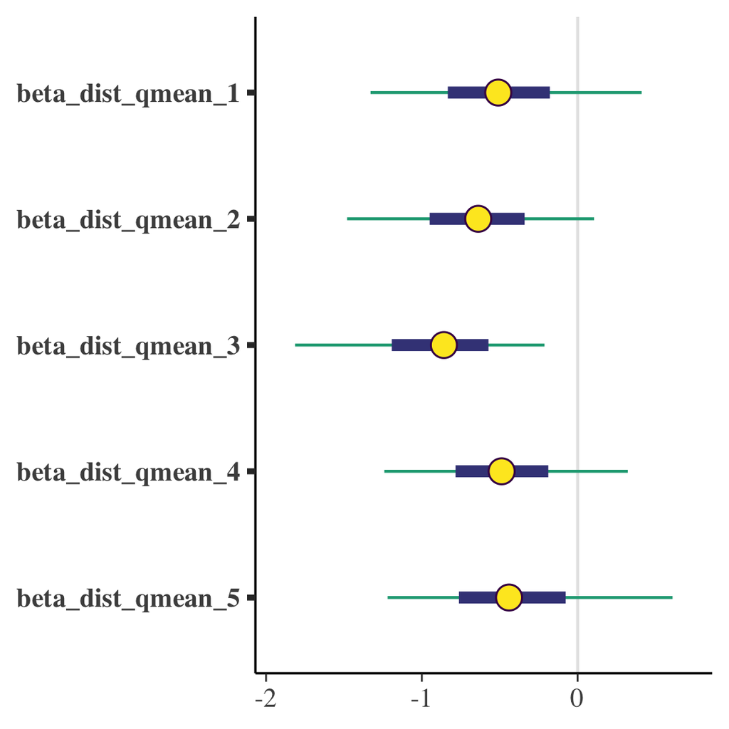

```r
## run changeBetaNames to make the parameter names understandable (so that we dont need to deal with matrix index)
dimnames(posterior)[[3]] = sampinfo::changeBetaNames(dimnames(posterior)[[3]],
                            beta = beta,
                            Q = max(format_data$qID),
                            S = max(format_data$sID))

bayesplot::mcmc_intervals(posterior, regex_pars = "^beta_dist_qmean")
```

## Additional diagnostics in Rstan

There are other diagnostics to pay attention to if the model is fit using Stan (HMC and NUTS)

```r
model_diag = getModelDiag(stan_data_fit = stan_data_fit)
print(model_diag[,c('divergent', 'max_tree')])
```

```
#>   divergent max_tree
#> 1         0        0
```

For example we need to make sure there is no divergent transitions, which is not uncommon for hierarchical models. When it happens we often need to:

- debug the rstan code
- try recovering the parameters
- reparameterize the model (for example, see Neal’s tunnel)
- increase alpha_delta, increase tree_maxdepth and decrease stepsize. We can explain this if time allows. Otherwise please refer to the part on HMC and NUTS in the next/last section.

If the maximum tree depth is hit in NUTS, we need to increase max_treedepth.

RStan will send warnings regarding these issues (remember to read it if the models are fit on GPC).

## Other topics:

### Neal’s Funnel

Note that there are two ways to parameterize Normal distributions (in hierarchical models):

- Centered parameterization:
  $$\beta \sim norml(\mu_{\beta}, \sigma_{\beta})$$
- Non-centered parameterization:
  $$\beta_{raw} \sim norml(0, 1)$$
  $$\beta = \mu_{\beta} + \sigma_{\beta} \beta_{raw}$$

If the individual level data are not very informative (and thus the individual parameters, $\beta$, are influenced by the group level priors $\mu_{\beta}$ and $\sigma_{\beta}$ a lot), it is much better to use the non-centered approach. Detailed explanations can be found here:

- RStan manual 22.7 [Link](https://mc-stan.org/docs/2_23/stan-users-guide/reparameterization-section.html)
- Betancourt, M., & Girolami, M. (2015). Hamiltonian Monte Carlo for hierarchical models. Current trends in Bayesian methodology with applications, 79(30), 2-4. [Link](https://arxiv.org/pdf/1312.0906.pdf)

Intuitively, when $\sigma_{\beta}$ is small, $\beta$ tends to be very close to $\mu_{\beta}$. When $\sigma_{\beta}$ is large, $\beta$ varies a lot. That forms a tunnel shape. The stepsize needed for exploring the ‘neck’ is much much smaller than that required for the ‘body’. Hence there’s no single stepsize that stan can use to sample efficiently.  
If we use the non-centered parameterization, then conditional on the data, the actively sampled parameters becomes independent from each other.

### HMC and Nuts

- Hamiltonian Monte Carlo explained. [Link](http://arogozhnikov.github.io/2016/12/19/markov_chain_monte_carlo.html)
- Betancourt, M. (2017). A conceptual introduction to Hamiltonian Monte Carlo. arXiv preprint arXiv:1701.02434. [Link](https://arxiv.org/pdf/1701.02434.pdf)
- Hoffman, M. D., & Gelman, A. (2014). The No-U-Turn sampler: adaptively setting path lengths in Hamiltonian Monte Carlo. Journal of Machine Learning Research, 15(1), 1593-1623. [Link](http://www.jmlr.org/papers/volume15/hoffman14a/hoffman14a.pdf)